# Introdução à Ciência de Dados

Mestrado em Administração  
Aula 9

Prof. Washington Santos da Silva

IFMG - Campus Formiga

7 de maio de 2026

## Nesta Aula

**Módulo II: Fundamentos de Probabilidade e Simulação**

Esta é a segunta de quatro aulas do módulo:

1. Fundamentos de Probabilidade
2. **Variáveis aleatórias e distribuições de probabilidade**
3. Distribuições de probabilidade essenciais e resultados assintóticos
4. Simulação de Monte Carlo em Finanças: VPL, VaR e Expected Shortfall

## Lembrete

**Proposta da Disciplina**

A disciplina propõe a construção de um **sistema coerente para análise de dados**, e não uma coleção isolada de ferramentas.

- **CRISP-DM** organiza as etapas de um projeto com dados;
- **R e tidyverse** implementam a análise estatística, computacional e gráfica;
- **RStudio** estrutura o ambiente de trabalho e o projeto;
- **Git/GitHub** registram a evolução da análise e tornam o processo rastreável;
- **Quarto** integra texto, código, resultados e comunicação;
- **probabilidade, simulação e inferência** como fundamentos para modelagem.

A análise deve produzir resultados **rastreáveis, reprodutíveis e auditáveis**.

**Diretrizes para Aulas Mais Produtivas**

⌨️ **Código com método:**

95% dos erros são evitáveis com:

- Atenção na digitação
- Respeitar a sequência lógica de etapas
- Revisão antes de pedir ajuda
- Somente aprendemos uma linguagem se a praticamos

**Inteligência colaborativa:**

- Compartilhe conhecimento
- Resolva questões técnicas simples com colegas próximos
- Reserve ao professor as dúvidas conceituais complexas

**Capacidade de Resolver Problemas**

- Cada erro resolvido é uma evolução da sua habilidade analítica

## CRISP-DM: Onde Estamos?

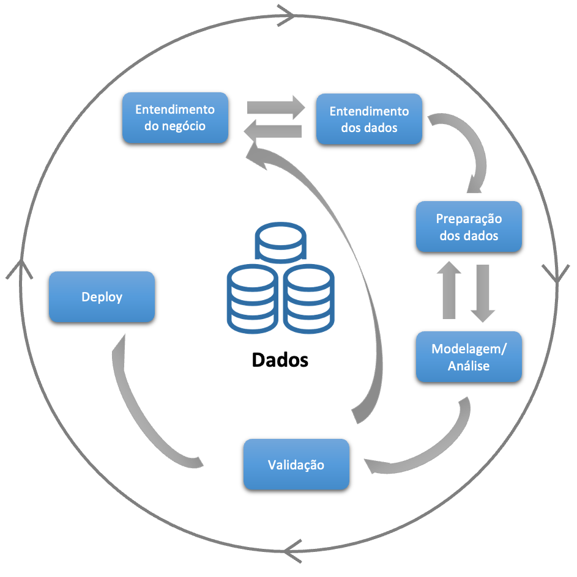

Fases da Metodologia CRISP-DM

**Contexto na Disciplina**

Na metodologia **CRISP-DM**, a teoria da probabilidade fundamenta a fase de **modelagem**, pois fornece a linguagem formal para representar e quantificar a incerteza.

Ela sustenta:

- **geração dos dados**: amostragem e experimentos;
- **modelagem estatística**: estimação, inferência e previsão;
- **simulação e análise de risco**: avaliação de cenários sob incerteza.

# Fundamentos de Probabilidade e Simulação **II**

## Objetivos da Aula

**Ao final desta aula, espera-se que vocês sejam capazes de:**

- Compreender o conceito de variáveis aleatórias.
- Distinguir distribuições discretas e contínuas e calcular probabilidades usando função de probabilidade, densidade, FDA e quantis.
- Interpretar média, variância, desvio-padrão, assimetria e curtose como momentos de uma distribuição.
- Analisar relações entre variáveis aleatórias por meio de distribuições conjuntas, marginais, condicionais, independência, covariância e correlação.
- Aplicar esses conceitos a exemplos introdutórios de Finanças, risco, retorno, crédito e decisão sob incerteza.

# Variáveis Aleatórias

## Recapitulando a Aula 8

**A linguagem de eventos**

Na Aula 8 descrevemos a incerteza por meio de:

- um **experimento aleatório**;
- um **espaço amostral** $S$;
- **eventos** $A \subseteq S$;
- **probabilidades** $P(A)$.

Ou seja, a cada evento $A$, formado por resultados possíveis do experimento, associamos uma probabilidade $P(A)$:

$$A \subseteq S \quad \Longrightarrow \quad P(A).$$

## Recapitulando a Aula 8

**Exemplos**

Eventos típicos:

$$A=\{\text{cliente inadimplente}\},
\quad
B=\{\text{retorno diário negativo}\}.$$

Cada um recebe sua probabilidade:

$$P(A)=P(\text{inadimplência}),
\quad
P(B)=P(\text{retorno negativo}).$$

Cada $P(\cdot)$ responde a **uma** pergunta sobre **um** evento.

## Limitações

**E quando os valores possíveis são muitos? Ou infinitos?**

- Na Aula 8, atribuímos $P(A)$ a cada evento $A \subseteq S$.
- Isso basta enquanto os eventos de interesse forem **poucos e enumeráveis**.
- Mas há um problema de **escala** — e, no caso contínuo, algo mais.

## Caso discreto

**Numa carteira com $N=1.000$ clientes, *quantos* ficam inadimplentes?**

- Cada valor $k \in \{0,1,\dots,1.000\}$ define um evento $\{X=k\}$.
- Seriam **1.001** atribuições isoladas $P(\{X=k\})$.
- A linguagem de eventos *funciona*, mas exige listar muitas probabilidades individualmente — sem oferecer uma forma unificada de descrever $X$.
- Obstáculo **operacional**.

## Caso contínuo

**E o retorno diário $X \in \mathbb{R}$?**

- Se o retorno pode assumir qualquer valor em um intervalo da reta real, seus valores possíveis formam um conjunto **infinito não enumerável**.
- Cada valor $x$ define um evento $\{X=x\}$, mas, no caso contínuo,

$$P(\{X=x\})=0.$$

- Assim, descrever o fenômeno ponto a ponto não permite obter probabilidades relevantes, como

$$P(a \leq X \leq b).$$

- Obstáculo **conceitual**: é preciso tratar **intervalos de valores**, não valores isolados.

## Descrever $X$ de forma unificada

**A distribuição como objeto**

- Queremos descrever **como a probabilidade se distribui** ao longo dos valores e também calcular **características** dessa distribuicão, como $E(X)$, $V(X)$.
- Isso exige tratar a totalidade dos valores possíveis como um **único objeto matemático**.
- É necessário associar a cada resultado um **número** e falar de probabilidade sobre esses números de forma unificada.

## $S$ pode não ser numérico

**E quando os resultados nem são números?**

Espaços qualitativos típicos:

- **Situação do cliente:** $S_1=\{\text{adimplente},\,\text{em atraso},\,\text{inadimplente}\}$.
- **Rating:** $S_2=\{\text{AAA},\text{AA},\text{A},\text{BBB},\text{BB},\text{B},\text{C}\}$.
- **Retorno (qualitativo):** $S_3=\{\text{positivo},\,\text{estável},\,\text{negativo}\}$.
- Ainda podemos atribuir $P(\text{AAA})$, $P(\text{em atraso})$, etc.

## $S$ pode não ser numérico

**E quando os resultados nem são números?**

- A **distribuição** sobre categorias **existe** (cada categoria recebe sua probabilidade).
- Mas o **valor esperado** $E(X)$ e a **variância** $V(X)$, **não**.
- Solução: **traduzir** cada resultado em um número.
- Ex.: $\text{inadimplente}\mapsto 1$, demais $\mapsto 0$, permite somar para contar quantos inadimplentes há na carteira.
- Isto é, precisamos do conceito de **variável aleatória**.

## Variável Aleatória

**Conceito fundamental**

- Variáveis aleatórias são um dos conceitos mais importantes e fundamentais da teoria da probabilidade.

**Definição:**

- Uma variável aleatória é uma **função** que associa um número real a cada resultado possível do espaço amostral $S$.

## Variável Aleatória

**Exemplo Simples**

Como exemplo, considere o lançamento de uma moeda, que tem como resultado possível cara (H) ou coroa (T).

Podemos escrever o resultado numericamente, atribuindo $X = 1$ se a moeda der cara e $X = 0$ se der coroa.

$$X =
\begin{cases}
1, & \text{se } H,\\
0, & \text{se } T.
\end{cases}$$

O resultado $X$ é aleatório, pois seu valor depende do resultado do lançamento da moeda.

## Variável Aleatória

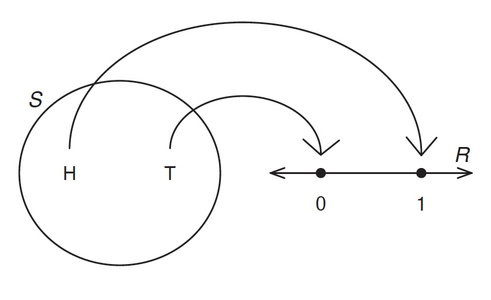

Uma variável aleatória é uma **função**. A incerteza está no resultado do experimento; depois que o resultado é observado, observa-se também o valor assumido pela função.

## Variável Aleatória

**Conceito fundamental**

Se $S$ é o espaço amostral, escrevemos:

$$X: S\to\mathbb{R}.$$

Para cada resultado possível $s\in S$, a variável aleatória atribui um valor numérico $X(s)$.

Portanto, uma variável aleatória $X$ mapeia os resultados de $S$ para os números reais, e a probabilidade definida sobre eventos em $S$ **induz** uma **distribuição de probabilidade** para $X$.

## Tipos de Variáveis Aleatórias

**Variável Aleatória **Discreta****

**Def.** Uma variável aleatória $X$ é dita **discreta** se existe um conjunto finito ou infinitamente enumerável $S \subset \mathbb{R}$ tal que $P(X \in S)=1$.

Nesse caso, o **suporte** de $X$, denotado por $S_X$, é o conjunto dos valores que $X$ assume com probabilidade positiva:

$$S_X = \{x \in \mathbb{R} : P(X=x)>0\}.$$

## Variáveis Aletórias Discretas

**Exemplos de Suporte Infinito**

- **Número de meses até o default de uma empresa ou contrato de crédito.**
- **Tempo de atingimento, medido em pregões,** até que o preço de uma ação alcance o patamar necessário para disparar uma ordem automática de venda (take profit), encerrando a posição com o lucro planejado.

## Tipos de Variáveis Aleatórias

**Variável Aleatória **Contínua****

**Def.** Uma variável aleatória (X) é dita **contínua** se sua *função de distribuição acumulada* $F_X(x)=P(X\leq x)$ é uma função contínua.

Nesse caso, $X$ não concentra probabilidade em valores isolados:

$$P(X=x)=0, \quad \text{para todo } x \in \mathbb{R}.$$

Assim, probabilidades são calculadas em **intervalos**, como

$$P(a \leq X \leq b).$$

O **suporte** de $X$ pode ser entendido como a região da reta real onde a distribuição de $X$ está concentrada.

## Variável Aleatória

**Síntese**

- Uma variável aleatória $X$ transforma os resultados de um experimento aleatório em valores numéricos.
- Ao fazer isso,$X$ **induz uma distribuição de probabilidade**, a partir da qual podemos estudar probabilidades, valor esperado, variância, quantis e relações entre variáveis.

# Distribuições de Probabilidade

## Distribuição de Probabilidade

**Conceito geral**

A **distribuição de probabilidade** de uma variável aleatória $X$ descreve como a probabilidade está associada aos valores, ou intervalo de valores, que $X$ pode assumir.

Ela permite responder perguntas como:

$$P(X = x), \qquad P(a \leq X \leq b), \qquad P(X \in A).$$

Assim, a distribuição de $X$ reúne toda a informação probabilística sobre a variável aleatória.

## Distribuição de Probabilidade

**Como representar uma distribuição?**

A distribuição de probabilidade de uma variável aleatória pode ser descrita por diferentes funções, dependendo do tipo de variável e da pergunta de interesse.

Para VA **discretas**, usamos a **função de probabilidade**:

$$p_X(x)=P(X=x).$$

Para VA **contínuas**, usamos a **função densidade de probabilidade**, que permite calcular probabilidades em intervalos:

$$P(a \leq X \leq b).$$

Em ambos os casos, a **função de distribuição acumulada** descreve probabilidades acumuladas:

$$F_X(x)=P(X\leq x).$$

Nos próximos slides, estudaremos cada uma dessas representações.

## Função de Probabilidade

**Definição**

A funçao de probabilidade<sup>1</sup> de uma VA **discreta** $X$ é a função $f_X(x)$, tal que para qualquer número real $x$:

$$f_X(x) = P(X = x)$$

A função de probabilidade tem propriedades induzidas pela definição axiomática de probabilidade. Em particular:

$$\begin{align*}
0 \leq f_X(x_i) \leq 1 \\
\sum_i f_X(x_i) = 1 \\
P(A) = P(X \in A) = \sum_{x_i \in A} f_X(x_i)
\end{align*}$$

[^1]: também denominada função massa de probabilidade

## Funções de Probabilidade

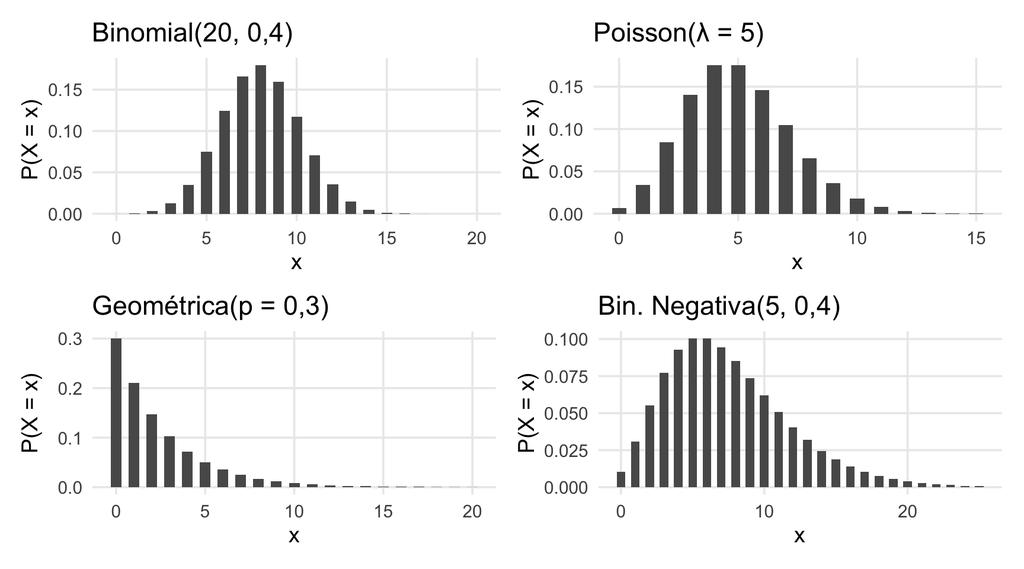

Figura 1: Funções de probabilidade de variáveis aleatórias discretas ($P(X = x)$ calculadas para cada $X = x$.

## Função Densidade de Probabilidade

**Definição**

Uma função é uma função densiade de probabilidade (FDP) se, e somente se:

$$\begin{align*}
f_X(x_i) \geq 0 \quad \text{(pode ser maior que 1)}\\
\int f_X(x) = 1 \quad \text{(integral = 1, ao invés da soma)}
\end{align*}$$

Isto é, uma FDP é uma função não negativa que é integrável e cuja integral resulta em um.

Pelo teorema fundamental do cálculo, temos que:

$$P(A) = P(a \leq X \leq b) = \int_{A} \underbrace{f_X(x)}_{\text{Esta é a fdp}}\, dx$$

Isso implica que a probabilidade de $X$ estar no intervalo $[a,b]$ é a integral da densidade sobre $[a,b]$. Isso mostra que a área sob a FDP são probabilidades.

## Função Densidade de Probabilidade

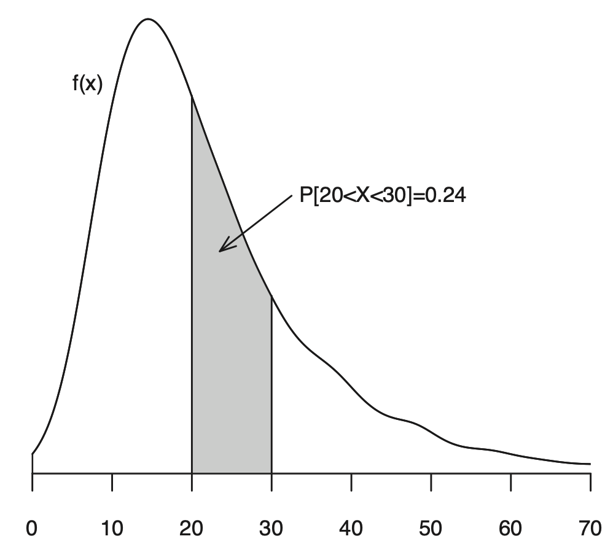

A área sombreada sob a curca corresponde à $P(20 \leq X \leq 30) = \int_{20}^{30} f_X(x)\,dx= 24$% de probabilidade de $X$ estar entre $20$ e $30$.

## Função Densidade de Probabilidade

**Soma de Riemann (regra do ponto médio)**

A probabilidade

$$P(a \le X \le b)=\int_a^b f(x)\,dx$$

pode ser aproximada pela soma das áreas de retângulos.

Particionando $[a,b]$ em $n$ subintervalos de largura $\Delta x=(b-a)/n$ e tomando $x_i^*$ como ponto médio do $i$-ésimo subintervalo, obtemos:

$$S_n=\sum_{i=1}^{n} f(x_i^*)\,\Delta x.$$

Quando $n\to\infty$ e $\Delta x\to 0$:

$$S_n \longrightarrow \int_a^b f(x)\,dx = P(a \le X \le b).$$

- Riemann não estava apenas formalizando a área sob uma curva. Seu objetivo estava ligado ao estudo de séries trigonométricas e à necessidade de integrar funções mais irregulares. Seu insight foi **definir a integral como o limite de somas finitas sobre partições cada vez mais finas**.

A animação a seguir ilustra essa convergência.

[interactive chart not shown]

Soma de Riemann $S_n$ para $n \in \{2, 4, 8, \ldots, 256\}$.

## Integral e Probabilidade

**Por que a integral mede a probabilidade?**

A integral não aparece por uma analogia “mística” entre área e probabilidade.

Para uma variável aleatória contínua, pontos isolados não carregam probabilidade:

$$P(X=x)=0.$$

Por isso, a probabilidade deve ser atribuída a intervalos. A função densidade $f_X(x)$ mede a concentração local de probabilidade ao redor de $x$.

Em um intervalo pequeno de largura $\Delta x$,

$$P(X \in [x_i,x_i+\Delta x])
=
\int_{x_i}^{x_i+\Delta x} f_X(x)\,dx
\approx f_X(x_i^*)\Delta x.$$

Somando muitos intervalos pequenos entre $a$ e $b$, obtemos

$$P(a \le X \le b)
\approx
\sum_{i=1}^n f_X(x_i^*)\Delta x.$$

Quando a largura dos intervalos tende a zero, essa soma converge para

$$P(a \le X \le b)
=
\int_a^b f_X(x)\,dx.$$

Portanto, a integral aparece porque ela é o **limite** da soma de pequenas contribuições de probabilidade ao longo de um intervalo.

O limite formaliza a ideia de aproximações sucessivamente mais refinadas.

Na soma de Riemann, cada $S_n$ é uma soma finita de áreas de retângulos:

$$S_n=\sum_{i=1}^{n} f_X(x_i^*)\Delta x.$$

Quando refinamos a partição, a maior largura dos subintervalos tende a zero. Se as somas se aproximam de um mesmo valor, esse valor é a integral:

$$\int_a^b f_X(x)\,dx
=
\lim_{\max \Delta x_i \to 0}
\sum_{i=1}^{n} f_X(x_i^*)\Delta x_i.$$

Assim, o limite não é uma etapa mística: é o modo rigoroso de transformar aproximações finitas cada vez melhores em uma definição matemática.

## Funções Densidade de Probabilidade

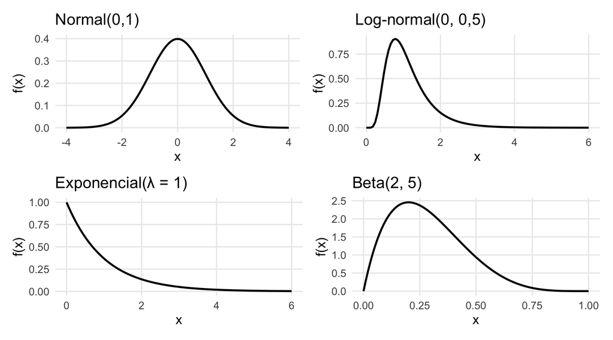

Figura 2: Funções densidade de probabilidade de variáveis aleatórias contínuas.

## Função de Distribuição Acumulada

**Definição**

A **função de distribuição acumulada** (FDA) de uma variável aleatória $X$ (discreta ou contínua) é:

$$F_X(x) = P(X\leq x)$$

Ou seja, $F_X(x)$ é a probabilidade de observar um valor de $X$ menor ou igual a $x$.

Propriedades fundamentais:

1. $0 \leq F_X(x) \leq 1$;
2. $F_X(x)$ é não decrescente;
3. $\lim_{x\to -\infty}F_X(x)=0$;
4. $\lim_{x\to \infty}F_X(x)=1$;
5. $F_X$ é contínua à direita: $\lim_{t\downarrow x}F_X(t)=F_X(x)$.

## FDA: Variável Aleatória Discreta

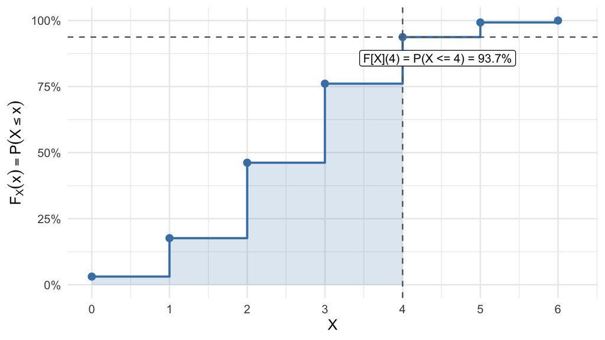

Figura 3: A região sombreada ajuda a visualizar a acumulação até X=4, mas a probabilidade acumulada não é a área sob a FDA. Em uma FDA discreta, a probabilidade acumulada até 4 é a altura da função nesse ponto: $F_{X}(4)=P(X≤4)$.

## FDA: Variável Aleatória Contínua

**Descrição**

Para uma variável aleatória contínua, a probabilidade acumulada até $x_0$ é:

$$F_X(x_0) = P(X\leq x_0)=\int_{-\infty}^{x_0} f_X(t)\,dt.$$

Ou seja: a probabilidade acumulada é a **área sob a função** até $x_0$.

## FDA: Variável Aleatória Contínua

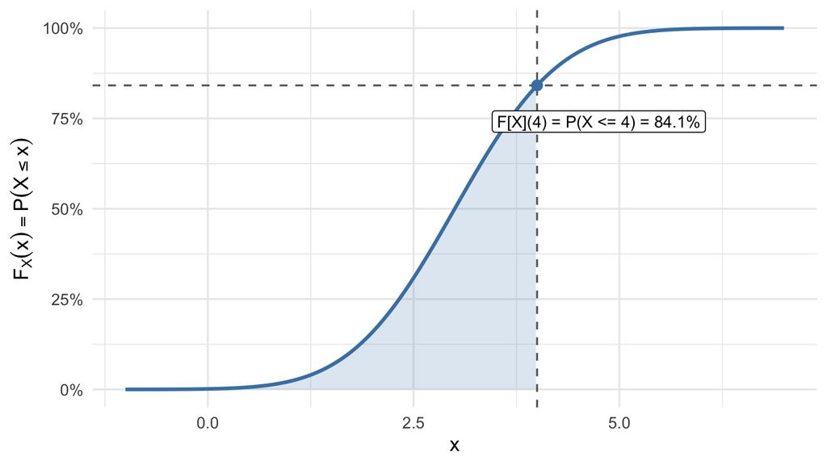

Figura 4: Função de distribuição acumulada de uma VA contínua.

## Função de Distribuição Acumulada

**Probabilidades de Intervalos**

Para qualquer variável aleatória:

$$P(a < X \leq b) = F_X(b) - F_X(a).$$

No caso contínuo, como $P(X = a) = 0$, normalmente escrevemos:

$$P(a\leq X\leq b) = F_X(b) - F_X(a).$$

O princípio geral é: probabilidades de intervalos podem ser obtidas como diferenças entre probabilidades acumuladas

## Função de Distribuição Acumulada

**Probabilidades de Intervalos: VA Discreta**

No caso discreto, é preciso ter cuidado com os pontos incluídos no intervalo, porque uma variável discreta pode ter probabilidade positiva em um valor específico.

Quando o extremo esquerdo também está incluído, a massa em $a$ precisa entrar no cálculo:

$$P(a\leq X\leq b)=F_X(b)-F_X(a)+P(X=a).$$

Equivalentemente, usando o limite à esquerda de $F_X$ em $a$:

$$P(a\leq X\leq b)=F_X(b)-F_X(a^-).$$

## Probabilidade em um intervalo via FDA

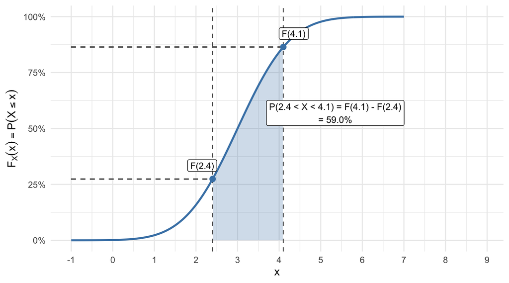

Figura 5: Cálculo de $P(2.4 < X < 4.1)$ usando a FDA de uma distribuição normal.

## Função de Distribuição Acumulada

**Por que usar a FDA?**

Como vimos, para VA contínuas, probabilidades envolvem integrais da função densidade de probabilidade (fdp).

Em vez de integrar numericamente a densidade a cada cálculo, usamos funções especializadas que calculam a FDA, como `pnorm()`, `pexp()`, entre outras de R.

Isso costuma ser mais eficiente, mais estável e menos sujeito a erros.

$$P(a \leq X \leq b) = F(b) - F(a).$$

```r
# Se X ~ N(0, 1):
# P(-1 <= X <= 1) = F(1) - F(-1)

pnorm(1) - pnorm(-1)
```

```
[1] 0.68269
```

## Apenas Representações Alternativas

**Síntese**

- As funções de probabilidade, de densidade de probabilidade e de distribuição acumulada para uma VA particular contém exatamente a mesma informação sobre sua distribuicão, apenas em forma diferente.
- Faz sentido, então, perguntar se, dada a função de distribuição acumulada, seria possível recuperar a função densidade e vice-versa?
- Sim, e para VA Contínuas podemos obter com:

$$\begin{align*}
F_X(x) = P(X \leq x) = \int_{-\infty}^x f_X(s)dx \\
f_X(x) = \frac{dF_X(x)}{dx}
\end{align*}$$

## Quantis

**Inversa da Função de Distribuição Acumulada**

A FDA parte de um valor e calcula uma probabilidade:

$$x \longmapsto F_X(x)=P(X\leq x).$$

Um **quantil** faz o caminho inverso: parte de uma probabilidade $\alpha$ e retorna o menor valor que acumula pelo menos essa probabilidade:

$$q(\alpha) = \inf\{x : F_X(x) \geq \alpha\}.$$

Lemos essa expressão como: o quantil de ordem $\alpha$ é o menor valor $x$ cuja probabilidade acumulada é pelo menos $\alpha$.

Se $F_X$ é contínua e estritamente crescente, então, podemos obter a função quantil como a inversa da FDA:

$$q(\alpha) = F_X^{-1}(\alpha).$$

## Quantis

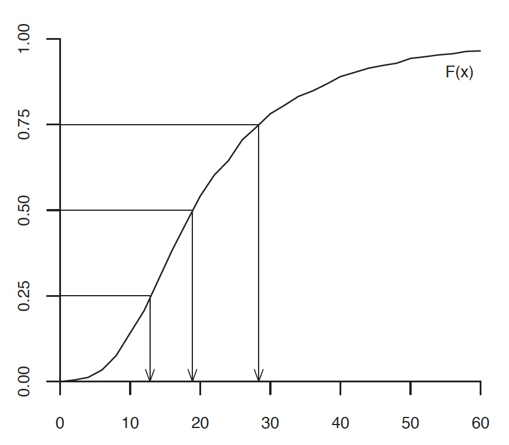

A função quantil $q(\alpha)$ é uma função de $[0,1]$ para o suporte de $X$.

## Quantis

**Quantis especiais**

Alguns quantis têm nomes especiais e indicam a proporção acumulada da distribuição.

- A **mediana** é o quantil 0,50: deixa 50% da distribuição à esquerda.
- Os **quartis** são os quantis 0,25, 0,50 e 0,75: dividem a distribuição em quatro partes. $Q_1$, $Q_2$ e $Q_3$ acumulam 25%, 50% e 75%.
- Os **decis** são os quantis 0,10, 0,20, …, 0,90: dividem a distribuição em dez partes. O 8º decil acumula 80%.
- Os **percentis** são os quantis 0,01, 0,02, …, 0,99: dividem a distribuição em cem partes. O 95º percentil é o quantil 0,95 e acumula 95%.

Quantis são medidas úteis da **posição** relativa de uma distribuição.

Eles são medidas de posição porque identificam valores (da VA) que ocupam posições específicas na distribuição, determinadas pela proporção acumulada de observações ou de probabilidade à esquerda desses valores.

## Distribuiçõees de Probabilidade

**O que você deve saber?**

Uma distribuição de probabilidade descreve como a incerteza sobre uma variável aleatória ($X$) é modelada. Você deve saber:

- **Como reconhecer uma distribuição válida**: valores não negativos e massa total, ou área total, igual a 1.
- **O que a função representa**: probabilidade, no caso discreto, ou densidade, no caso contínuo.
- **Quais parâmetros definem a distribuição** e como eles afetam sua forma.
- **Como calcular probabilidades, probabilidades acumuladas e quantis** usando funções prontas.
- **Como simular valores (pseudo-)aleatórios** a partir da distribuição.
- **Como obter momentos importantes**, como valor esperado, variância e outros momentos.

# Momentos de uma Distribuição

## Por eue resumir uma distribuição?

**Motivação dos momentos**

- Há muita informação em uma função (densidade) de probabilidade
- Às vezes, informação demais.
- Talvez não nos importemos exatamente com qual é o formato da  
  distribuição, mas apenas queiramos resumir algumas de suas características mais marcantes:
  - onde ela está centralizada;
  - quão dispersa está;
  - onde atinge seu pico;
  - se é simétrica ou assimétrica;
  - quão pesadas são suas caudas.
- Podemos definir os **momentos** de uma distribuição para nos ajudar a **resumir** (ou **sumarizar**) algumas dessas características mais marcantes.

## Momentos como resumos da distribuição

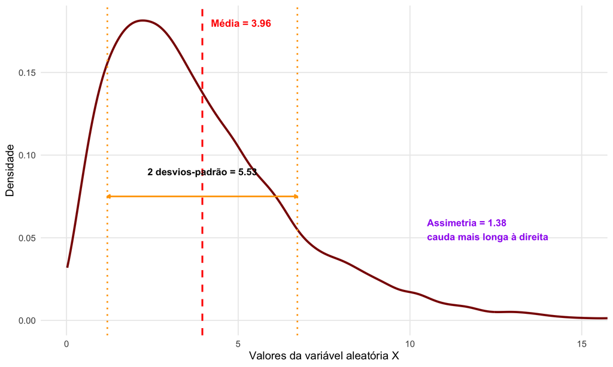

Média, desvio-padrão e assimetria resumem, respectivamente, posição, dispersão e forma da distribuição.

## Valor Esperado

**Definição**

- O valor esperado<sup>1</sup> de uma variável aleatória $X$ é denotada por $E[X]$.
- **Caso Discreto:**
  $$E(X) = \sum_i x_i\,P(X=x_i)$$
- **Caso Contínuo** (com densidade $f_X(x)$):
  $$E(X) = \int_{-\infty}^{\infty} x f_X(x)\,dx$$

**Condição de Existência:**

O valor esperado é bem definido apenas se o somatório ou a integral forem convergentes ($E(|X|) < \infty$).

[^2]: também denominado média, expectativa ou esperança matemática.

## Valor Esperado

**Interpretação**

É importante entender que, embora $X$ seja uma variável aleatória, o valor esperado $E[X]$ não é uma variável aleatória. É uma **característica fixa** da distribuição de probabilidade de $X$.

Sendo uma característica fixa da distribuição, o $E(X)$ **não** é necessariamente:

- O valor mais provável (este seria a *moda*);
- Um valor que de fato possa ocorrer na prática (ex: média de um dado é $3,5$);
- Uma previsão isenta de incerteza ou risco (avaliado pela variância).

$E(X)$ descreve o valor **típico** de $X$ quando o experimento aleatório subjacente é repetido muitas vezes.

## Valor Esperado

**Propriedades de $E(X)$**

1. $E(c) = c$, sendo $c$ uma constante.
2. $E[cX]=cE[X]$, se $c$ é uma constante e $X$ uma VA.
3. **Teorema (Linearidade do Valor Esperado)**: Sendo $Y = a + bX$, para $a$ e $b$ constantes, $E(a + bX) = a + bE(X)$.
4. Para $Y = X_1 + X_2 + \ldots + X_n$, temos que $E(Y) = E(X_1) + E(X_2) + \ldots + E(X_n)$. (**Nota:** As VAs não precisam ser independentes!)
5. Para $Y = a_1 X_1 + a_2 X_2 + \ldots + a_n X_n$, temos que $E(Y) = a_1 E(X_1) + a_2 E(X_2) + \ldots + a_n E(X_n)$.

## O Que é um momento?

**Valores esperados de funções de $X$**

Depois de definir valor esperado, podemos definir momentos.

De forma geral, momentos são **valores esperados** calculados a partir de potências de uma variável aleatória.

O $k$-ésimo momento não central de $X$ é:

$$E[X^k].$$

O $k$-ésimo momento central de $X$ é:

$$E[(X-\mu)^k],
\quad \text{em que } \mu=E[X].$$

Leitura:

- momentos não centrais descrevem potências de $X$ em torno de zero;
- momentos centrais descrevem desvios de $X$ em torno da média;
- os momentos só são bem definidos quando esses valores esperados existem.

## Variância e Desvio-Padrão

**Dispersão ao redor da média**

Se $\mu=E[X]$, a **variância** de $X$ é:

$$V(X)=E[(X-\mu)^2].$$

A variância é, portanto, o **segundo momento central** de $X$.

A variância é uma medida da variabilidade (dispersão) de uma VA. Ela mede o desvio quadrático média em relação ao valor esperado:

Uma expressão equivalente, frequentemente útil em cálculos, é:

$$V(X) = E[X^2]-[E[X]]^2.$$

O **desvio-padrão** é:

$$\sigma = \sqrt{V(X)}.$$

Como $\sigma$ está na mesma unidade de $X$, é uma medida mais natural de variabilidade de uma VA.

## Padronizando uma VA

**Descrição**

- Quando uma VA $X$ possui $E(X) = \mu$ e desvio-padrão $\sigma$, sua versão **padronizada** possui:

$$E\biggl[\frac{X - \mu}{\sigma}\biggr] = \frac{E(X) - \mu}{\sigma} = \frac{\mu - \mu}{\sigma} = 0$$

$$V\biggl[\frac{X - \mu}{\sigma}\biggr] = V\biggl[\frac{X}{\sigma} - \frac{\mu}{\sigma}\biggr]= V\biggl[\frac{X}{\sigma}\biggr] = \frac{1}{\sigma^2}V(X) = \frac{\sigma^2}{\sigma^2} = 1$$

- Portanto, uma VA **padronizada** possui necessariamente $E(X) = 0$ e $V(X) = \sigma = 1$.

## Variância

**Propriedades de $V(X)$**

1. $V(X) \geq 0$.
2. $V(c) = 0$, sendo $c$ uma constante.
3. $V(X + c) = V(X)$, se $c$ é uma constante.
4. Se $Y = a + bX$, então $V(Y) = b^2 V(X)$.
5. $V(X) = E[(X - E(X))^2] = E(X^2) - [E(X)]^2$.
6. Se $Y = X_1 + X_2 + \ldots + X_n$ e as variáveis aleatórias $X_i$ são *independentes*, então $V(Y) = V(X_1) + V(X_2) + \ldots + V(X_n)$.
7. Se $Y = a_1 X_1 + a_2 X_2 + \ldots + a_n X_n$ e as variáveis aleatórias $X_i$ são independentes, então $V(Y) = a_1^2 V(X_1) + a_2^2 V(X_2) + \ldots + a_n^2 V(X_n)$.

## Assimetria

**Descrição**

- A assimetria de uma VA $X$ é o seu **terceiro momento padronizado**:

$$ass(X) = E\biggl[ \biggl(\frac{X - \mu}{\sigma}\biggr)^3 \biggr] = \frac{E[(X - \mu)^3]}{\sigma^3}$$

- A padronização torna a assimetria comparável entre distribuições com diferentes primeiro e segundo momentos, i.e, a assimetria é independente da unidade de medida por construção.
- $ass(X)$ mede a assimetria em uma distribuição, pois a terceira potência depende do sinal da diferença.
- Valores negativos da assimetria indicam que a chance de observar um valor negativo grande (em magnitude) é maior do que a chance de observar um valor positivo similarmente grande, e vice-versa.

## Assimetria

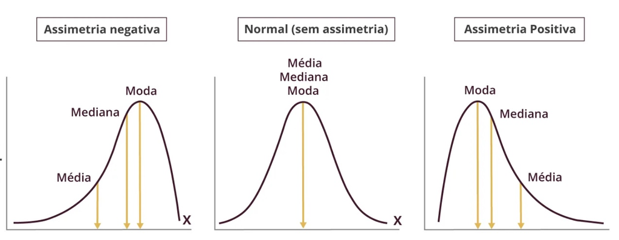

## Curtose

**Descrição**

- A curtose de uma VA $X$ é o seu **quarto momento padronizado**:

$$curtose(X) = E\biggl[ \biggl(\frac{X - \mu}{\sigma}\biggr)^4 \biggr] = \frac{E[(X - \mu)^4]}{\sigma^4}$$

- A curtose de uma VA é comumente comparada com a de uma VA com distribuição normal, que é 3.
- VAs com curtose maior que 3, uma característica comum de distribuições de retornos financeiros, são descritas como tendo caudas pesadas/grossas.
- Assim como a assimetria, a curtose é naturalmente independente de unidades e pode ser diretamente comparada entre variáveis aleatórias com diferentes médias e variâncias.

## Curtose

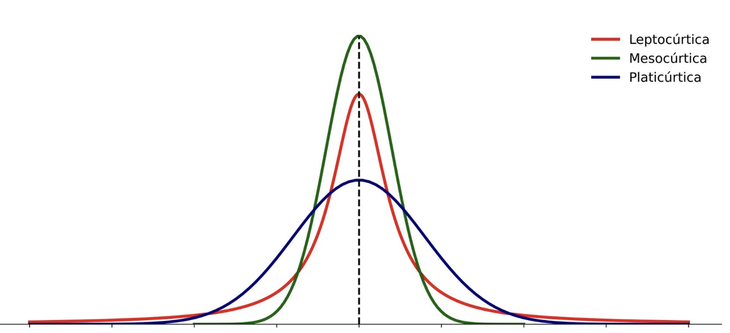

## Momentos e Medidas Derivadas

**Síntese dos resumos**

Agora podemos organizar os principais momentos e medidas derivadas:

| Característica | Expressão | Interpretação |
| --- | --- | --- |
| média | $E[X]$ | centro da distribuição |
| variância | $V(X)=E[(X-\mu)^2]$ | dispersão ao redor da média |
| desvio-padrão | $\sigma=\sqrt{V(X)}$ | dispersão na mesma unidade de $X$ |
| assimetria | $E[((X-\mu)/\sigma)^3]$ | direção da cauda mais longa |
| curtose | $E[((X-\mu)/\sigma)^4]$ | peso relativo dos extremos |

## Moda

**Definição**

Seja $X$ uma VA contínua com função densidade de probabilidade $f_X(x)$.  
A **moda** de $X$, denotada por $\text{moda}(X)$, é o valor $x^*$ tal que:

$$x^* = \arg\max_{x} f_X(x)$$

Isto é, a moda é o ponto em que a função densidade de probabilidade atinge seu valor máximo.

- Para distribuições **unimodais**, existe um único $x^*$.
- Para distribuições **multimodais**, existem vários valores de $x$ que maximizam $f_X(x)$.
- Em distribuições **uniformes contínuas**, todos os pontos no intervalo têm a mesma densidade, logo **não existe moda única**.

## Modalidade de uma VA

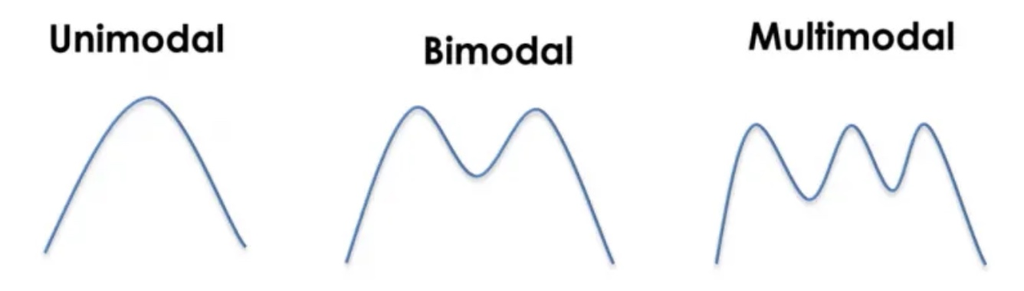

Distribuição unimodal, bimodal e multimodal.

# Relações Entre Variáveis Aleatórias

## Por Que Estudar Relações?

**Variáveis raramente aparecem isoladas**

Até aqui, descrevemos uma variável aleatória por vez:

- sua distribuição;
- sua FDA e seus quantis;
- seus momentos.

Mas, em aplicações financeiras, as perguntas quase sempre envolvem relações:

- retornos de dois ativos se movem juntos?
- inadimplência aumenta quando a renda cai?
- empresas mais alavancadas têm maior risco de dificuldade financeira?
- a distribuição dos retornos muda quando condicionamos à recomendação de um analista?

Para responder perguntas desse tipo, precisamos estudar variáveis aleatórias em conjunto.

## Distribuições de Probabilidade Bivariada

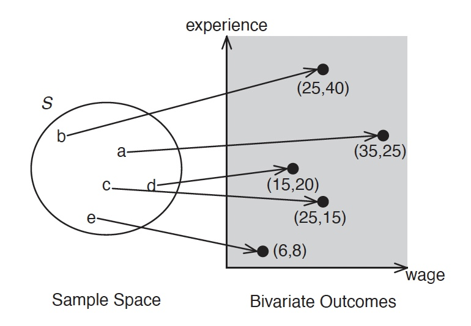

Distribuição bivariada entre salário e experiência profissional.

## Distribuições de Probabilidade Bivariada

**Relação entre salário e experiência profissional**

- Considere o par bivariado salário (em dólares) e experiência profissional (em anos).
- Estamos interessados em como os salários **variam** com a experiência e, portanto, em sua **distribuição conjunta**.
- A elipse é o espaço amostral com resultados aleatórios $(a, b, c, d, e)$. (Você pode pensar nos resultados como assalariados individuais em um ponto no tempo.)
- A figura representa os pares bivariados (salário, experiência profissional).
- As setas representam o mapeamento. Cada resultado é um ponto no espaço amostral.

## Distribuições Conjunta, Marginal e Condiciional

**Definição: Caso Bivariado**

#### Distribuição Conjunta

No caso contínuo, a **fdp conjunta** do vetor aletatório $(X, Y)$ é:

$$f_{XY}(x, y) = P((X,Y) \subset A) = \int \int_{A} f_{XY}(x, y)\,dx\,dy = 1$$

E a **FDA conjunta**

$$F_{X,Y}(x, y) = P(X \leq x \cap Y \leq y) = \int_{-\infty}^{y} \int_{-\infty}^x f_{XY}(x, y)\,dx\,dy = 1$$

Usamos “conjunta” para indicar especificamente que esta é a distribuição de múltiplas variáveis aleatórias, i.e, de um vetor aleatório.

#### Distribuição Marginal

1. Dada a fdp conjunta $f(x,y)$, as densidades marginais de $X$ e $Y$ são:

$$f_X(x) = \int_{-\infty}^{\infty} f_{XY}(x, y)\,dy$$

e

$$f_Y(y) = \int_{-\infty}^{\infty} f_{XY}(x, y)\,dx$$

2. Dada a FDA conjunta $F(x,y)$, as densidades marginais de $X$ e $Y$ são:

$$f_X(x) = \frac{d}{dx} F_X(x) = \int_{-\infty}^{\infty} f_{XY}(x, y)\,dy$$

e

$$f_Y(y) = \frac{d}{dy} F_Y(y) = \int_{-\infty}^{\infty} f_{XY}(x, y)\,dx$$

Essas densidades marginais são obtidas integrando em relação à outra variável, “removendo” sua influência da densidade conjunta.

#### Distribuição Condicional

1. Dada a fdp conjunta $f_{XY}(x, y)$, a **fdp condicional** de $Y$ dado $X = x$ é:

$$f_{Y|X}(y|x) = \frac{f_{XY}(x, y)}{f_X(x)}\, \text{para qualquer $x$ tal que $f_X(x) > 0$.}$$

2. Dada a FDA conjunta $F(x,y)$, se $F_{Y|X}(y|x)$ é diferenciável em relação à $y$ e $P(X = 0) > 0$, a **fdp condicional** de $Y$ dado $X = x$ é:

$$f_{Y|X}(y|x) = \frac{\partial}{\partial y} F_{Y|X}(y|x)$$

Podemos pensar na distribuição condicional como a distribuição de $Y$ para a **subpopulação** com um determinado valor de $X$, ou como a distribuição de $Y$ **atualizada** com a informação de que $X = x$ ocorreu.

## Arquivo `hansen-wage.rds`

**Fonte**

Dados utilizados em um livro de Brunce Hansen e extraídos da pesquisa *Current Population Survey (CPS - March/2009)* realizada pelo *U.S. Census Bureau*.

#### Arquivo `hansen-wage.rds`

- É uma **subamostra** dos dados princiapis
- Contém **trabalhadores civis em tempo integral**, **não imputados**, com salário-hora positivo
- Campos presentes (12 varia’veis): `age`, `female`, `hisp`, `education`, `earnings`, `hours`, `week`, `union`, `uncov`, `region`, `race`, `marital`.

#### Dicionário dos Dados

- `age`: idade (00–85 na codificação CPS).
- `education`: escolaridade** em **anos**,
- `earnings`: renda anual de **wage & salary** (pessoa).
- `hours`: horas trabalhadas por semana (pessoa).
- `week`: semanas trabalhadas no ano.
- `female`: (1=masc., 2=fem.).
- `marital`: (1..7; casado, viúvo, divorciado, etc.).
- `union`: sindicalizada(o): (1=é membro). `uncov` ← **A_UNCOV** (1=coberto por contrato).
- `region`: região (1=Nordeste, 2=Centro-Norte, 3=Sul, 4=Oeste).
- `race`: raça

#### Variáveis utilizadas

- **Salário-hora** (*Wage*):

  $$\text{wage} = \frac{\text{earnings}}{\text{hours}\times \text{week}}$$
- **Experiência** (*Experience*):

  $$\text{experience}=\max\{\text{age}-\text{education}-6,\;0\}$$
- **Educação** (*Education*): em **anos**

## Distribuição Conjunta Empírica

[interactive chart not shown]

## Densidades Condicionais Empíricas

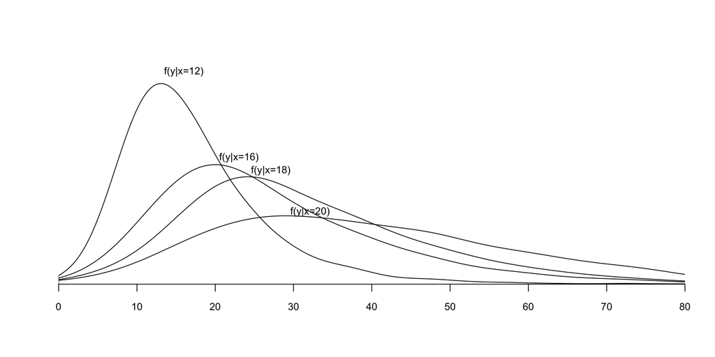

Figura 6: Densidade Condicional de Salário dada Educação.

## Densidade Condicional Empírica

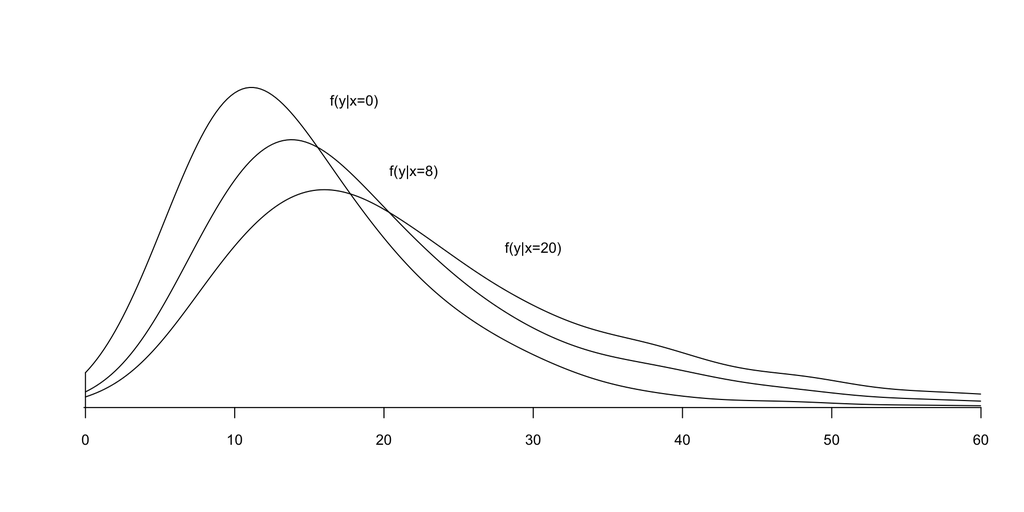

Figura 7: Densidade Condicional de Salário dada Experiência.

## Comparando as Densidades Condicionais

**Conclusão**

- Se compararmos as densidades condicionais na Figura 6 com as da Figura 7, podemos ver que o efeito da educação sobre os salários é consideravelmente mais forte do que o efeito da experiência.

## Por que não focar apenas em densidades conjuntas ou condicionais?

**Pergunta**

Se a distribuição conjunta resume toda a incerteza sobre variáveis aleatórias,  
**por que a econometria não se concentra apenas em estimar essas densidades conjuntas ou condicionais?**

#### Resposta

- **Alta dimensionalidade**  
  Estimar densidades em várias variáveis exige amostras enormes; na prática, raramente temos dados suficientes. Seria ineficiente.
- **Interpretação limitada**  
  Densidades conjuntas são difíceis de interpretar economicamente. Parâmetros econométricos (elasticidades, coeficientes) fornecem respostas mais claras.
- **Problemas de estimação não paramétrica**  
  Estimadores de densidade sofrem forte trade-off entre viés e variância, o que limita seu uso em amostras finitas.
- **Causalidade é central**  
  A econometria não busca apenas prever distribuições, mas identificar **relações causais**. A densidade conjunta sozinha não responde a essas questões.
- **Modelos estruturais são úteis**  
  Modelos paramétricos e semiparamétricos oferecem **resumos parsimoniosos** e testáveis de fenômenos econômicos.
- **Aplicações práticas**  
  Em vez de densidades complexas, modelos econométricos entregam métricas diretamente úteis: elasticidades, efeitos de políticas, betas de ativos, etc.

## Valor Esperado Condicional

**Definição**

- É um conceito muito importante em estatística e econometria.
- Um valor esperado condicional é o valor esperado de uma distribuição condicional.

#### Caso Discreto

Para VAs discretas, temos:

$$\begin{align*}
E[Y|X=x] &= \frac{f_{x,y}(x, y)}{f_{X}(x)}
\end{align*}$$

- Quando X é discreta, a expectativa condicional é o valor esperado de $Y$ dentro da subpopulação para a qual $X = x$.
- Por exemplo, se X é sexo, então $E[Y|X = x]$ é o valor esperado para homens e mulheres, separadamente.
- Se X é educação, então $E[Y|X = x]$ é o valor esperado para cada nível educacional.

#### Caso Contínuo

Para VAs contínuas, temos:

$$\begin{align*}
E[Y|X=x] &= \int_{-\infty}^{\infty} f_{Y|X}(y|x)\,dy \\
&= \frac{\int_{-\infty}^{\infty} y f(x,y)dy}{\int_{-\infty}^{\infty} f(x,y)dy}
\end{align*}$$

- Quando $X$ é contínua, a expectativa condicional é o valor esperado de $Y$ dentro da população infinitesimalmente pequena para a qual $X = x$.

## Covariância

**Covariância**

A **covariância** entre duas variáveis aleatórias $X$ e $Y$ tendo $E(X) = \mu_X$ e $E(Y) = \mu_Y$ é uma característica des sua distribuição conjunta.

É definida como:

$$\text{Cov}(X, Y) = E[(X - \mu_X)(Y - \mu_Y)] = E(XY) - E(X)E(Y)$$

Propriedades:

- **Simétrica**: $\text{Cov}(X, Y) = \text{Cov}(Y, X)$
- $\text{Cov}(X, Y) > 0$: variáveis tendem a cresce/decrescer juntas
- $\text{Cov}(X, Y) < 0$: uma cresce, a outra decresce, e vice-versa.
- Tem unidade: $\text{unid}(X) \cdot \text{unid}(Y)$

A covariância é como a **média dos produtos de desvios conjuntos**.

## Correlação

**Definição Correlação**

A correlação entre uma variável aleatória $X$, tendo $E(X) = \mu_X$ e desvio padrão $\sigma_X$, e uma variável aleatória $Y$, tendo $E(Y) = \mu_Y$ e desvio padrão $\sigma_Y$, é definida como:

$$\text{Cor}(X, Y) =
E\left[ \left( \frac{X - \mu_X}{\sigma_X} \right)\left( \frac{Y - \mu_Y}{\sigma_Y} \right) \right] = \frac{\text{Cov}(X, Y)}{\sigma_X \sigma_Y}$$

A **correlação** padroniza a covariância, removendo as unidades e está confinada ao intervalo $[-1, 1]$, podendo fornecer uma medida da força da **relação linear** entre $X$ e $Y$.

Propriedades:

É como comparar os **desvios padronizados**: ambos estão acima da média? quanto?

## Correlação entre Variáveis Aleatórias

**Correlação**

- Quando as variáveis aleatórias $X$ e $Y$ **não são independentes**, certos valores de $X$ tendem a estar associados a certos valores de $Y$. Ou seja, existe uma **relação ou associação** entre elas.
- Ao amostrarmos aleatoriamente pares $(X, Y)$ de sua **distribuição conjunta** de probabilidade, com médias marginais $\mu_X$ e $\mu_Y$, dizemos que há uma **associação positiva** se, em média, o valor de $(X - \mu_X)(Y - \mu_Y)$ é positivo.

Em outras palavras:

- Quando $X > \mu_X$, geralmente também temos $Y > \mu_Y$;
- Quando $X < \mu_X$, geralmente também temos $Y < \mu_Y$.

Já uma **associação negativa** ocorre se, em média, o produto $(X - \mu_X)(Y - \mu_Y)$ assume valores negativos — isto é, quando $X$ está acima da média ($X > \mu_X$), tende-se a observar $Y < \mu_Y$, e vice-versa.

## Propriedades

**Covariância e da Correlação**

1. $Cov(X,X) = V(X)$
2. $Cov(X,Y) = Cov(Y,X)$
3. $Cov(X,Y) = E(XY) - E(X)E(Y)$
4. Se $X$ e $Y$ são independentes (com momentos finitos), então $Cov(X,Y) = 0$.  
   Entretanto, $Cov(X,Y) = 0$ **não implica independência**, salvo em casos especiais  
   (ex.: distribuição normal bivariada).
5. $Cov(aX + b, cY + d) = ac Cov(X,Y)$
6. Para *quaisquer* VAs $X$ e $Y$, temos que $V(X + Y) = V(X) + V(Y) + 2(Cov(X,Y))$.
7. A correlação sempre satisfaz: $|\rho_{XY}| \leq 1 \rightarrow -1 \leq \rho_{XY} \leq 1$
8. $|\rho_{XY}| = 1$ se, e somente se, $Y = aX + b$ ($a \neq 0$)

# Lista de Exercícios

## Exercícios

**Site da disciplina**

- A lista de exercícios 5 está no site da disciplina.

## Referências

DEVORE, J. L. **Probabilidade e Estatística para Engenharia e Ciências**. São Paulo: Thomson, 2006.